# keyset

### 2.7. Correlation Analysis

As we can see below, there are correlations between customer price and developer proceeds, app apple ID and subscription apple ID, trial price and trial proceed but the other categories are not related to each other.

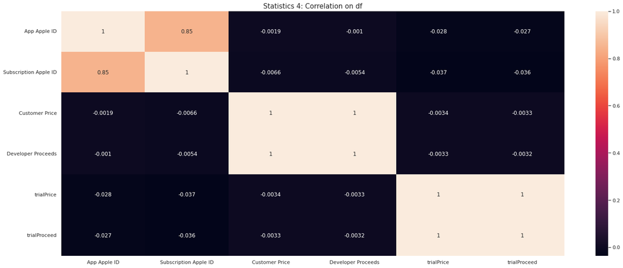

```python
df_corr = df.corr()
plt.subplots(figsize=(25,10))
sns.heatmap(df_corr, annot=True)
plt.title("Statistics 4: Correlation on df", fontsize=15)
```

### 2.8. Top Countries based on trial proceeds

The countries that pay the most trial proceeds are as follows. Vietnam and Colombia are tested apps more than any other country.

```python
pt2=df.groupby("Country").trialProceed.mean().sort_values(ascending=False)[:5]
 pt2
```

```
Country
VN    3268.421053
CO     857.142857
ID     535.252336
KR      75.067416
CL      36.930233
Name: trialProceed, dtype: float64
```

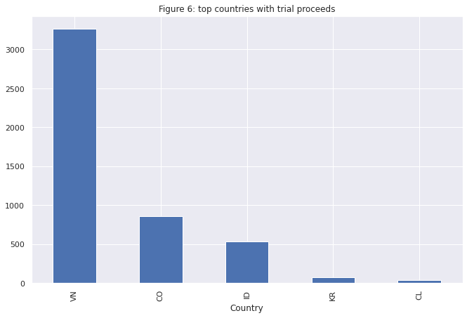

```python
pt2.plot.bar()
plt.title("Figure 6: top countries with trial proceeds")
```

### 2.9. Applications & Customer Price

As we see below, some applications are completely free and some applications are paid. The paid apps are Interview and Meeting Recorder, Secret Net VPN - Proxy Browser, Call Recorder - Save&Listen, Storico:Instagram story maker, Fax scan pdf and file manager respectively. The most paid applications are Interview and Meeting Recorder and Secret Net VPN - Proxy Browser.

```python
app_price_pt3=df.groupby('App Name')[['Customer Price']].mean()
app_price_pt3
```

| App Name | Customer Price |
| --- | --- |
| App Vault: Hide Photos & Files | 30.174815 |
| Art Meditation: Calm Coloring | 0.000000 |
| Call Blocker: Scam Spam Lookup | 45.413186 |
| Call Recorder - Save & Listen | 4459.589308 |
| Card Scanner to Contacts + OCR | 0.681591 |
| Earni: Earn Money & Video Call | 0.000000 |
| Fax - Scan PDF & Send Document | 944.780878 |
| File Manager: Music, PDF, Text | 450.164051 |
| Interview & Meeting Recorder | 11613.175661 |
| None | 40.128889 |
| RECRE8: Meditation & Sleep | 3.841875 |
| Scanner Unlimited: Scan & Sign | 29.678431 |
| Secret Net VPN - Proxy Browser | 10919.328353 |
| Sticker Maker: Fun, Meme & GIF | 0.000000 |
| Storico: Instagram Story Maker | 4340.270476 |
| Teleprompter Text & Word Timer | 8.384516 |
| Trading Troop: Signal Tracker | 0.000000 |

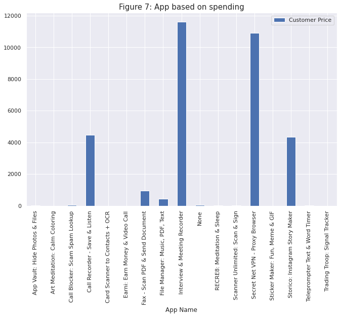

```python
app_price_pt3.plot(kind='bar')
plt.title("Figure 7: App based on spending", fontsize=15)
```